# 2016-0509-6306_Rolling_Sales_Analysis_StatenIsland

Manjula Kottegoda

June 8, 2016

## Rolling Sales Analysis Staten Island

This is to load and examine the Staten Island Rolling sales data as part of Live Session 04 Assignment for Group 4 (consisting of Gopinath Mavankal, Olasehinde Ogunbeku, Ryan Kelly and Manjula Kottegoda)

First we load the data. Raw file and a copy of partially cleansed data in to a master dataframe for analysis. Partial cleansing steps given in readme.

Initial views of the data show outliers that cloud the general patterns.

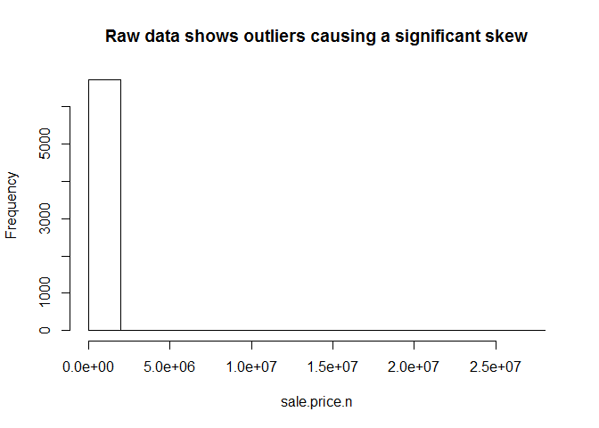

Outliers are more visible in this view from the partially cleansed data file as well. Majority of the population is below the $ 1000/Sqft price point.

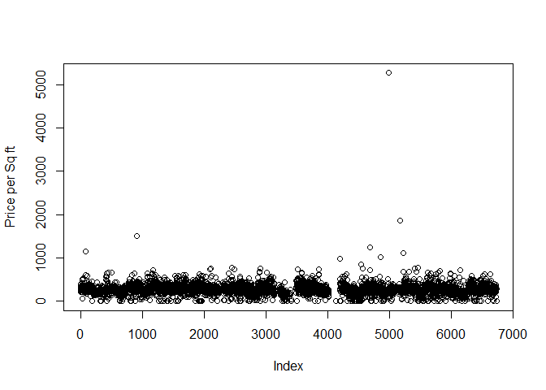

Using the Partially cleaned data we do the following analysis for the lower price point.

Figure 2.1 (below) shows all counts where price per square foot is less than $1000. We have omitted high value outliers in this view. The count in the lowest price point ‘bucket’ shows an abnormal spike. This is because of multiple sub $100 sales. These typically account for transfer of ownership rather than an actual sale. Figure 2.2 shows a more realistic market view on price vs. demand.

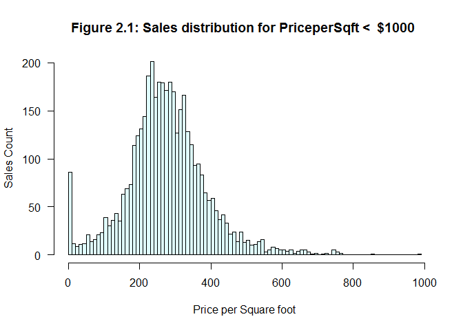

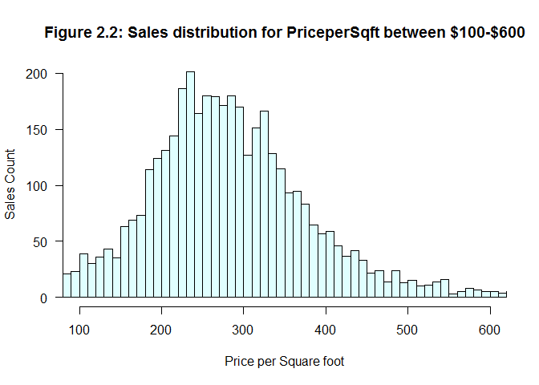

As seen in Figure 2.2 median price per square foot in Staten Island for sub 1000 range is $270.83. Overall Median price per square foot for entire borough of Staten Island is $294.4.

Furthermore the Median sales price for the entire borough of Staten Island is **$ 405000.00**.

The graph below shows the sales by neighborhood. The view below shows the most to least desirable neighborhoods based on sales.

[figure not shown]

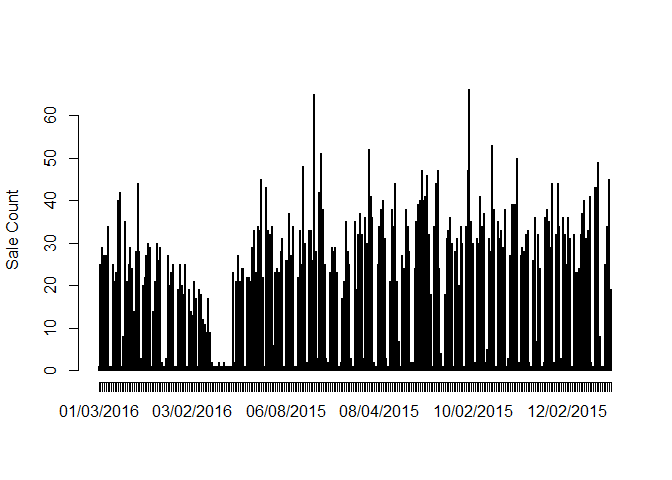